# Методология построения синхронных (опережающих) высокочастотных индикаторов

Ирина Голощапова

8 ноября 2016 г.

# Процентные риски

## Отбор частных индикаторов

Отбираем частные индикаторы на основе процентных ставок различных сроков в рамках следующих категорий:

- *Межбанковский рынок*. Ставки MIACR и Mosprime различных сроков.
- *Рынок корпоративных облигаций*. Средневзвешенный индекс эффективной доходности корпоративных облигаций IFX-Cbonds-YTM-eff.
- *Рынок государственных облигаций*. Ставки ГКО-ОФЗ различных сроков и спрэды между ставками различных сроков.

### Межбанковский рынок

#### MIACR

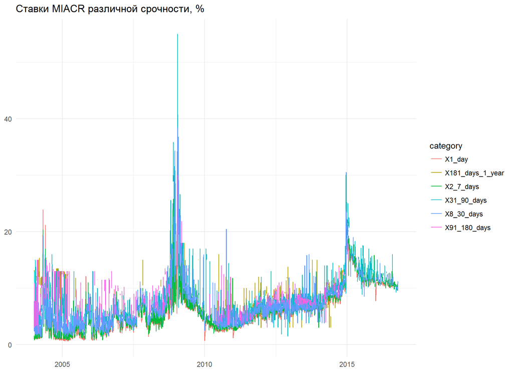

**Доля пропущенных значений в данных**

| X1_day | X181_days_1_year | X2_7_days | X31_90_days | X8_30_days | X91_180_days |
| --- | --- | --- | --- | --- | --- |
| 0 | 0.7617 | 0.03277 | 0.3064 | 0.112 | 0.6681 |

**Выбранное**

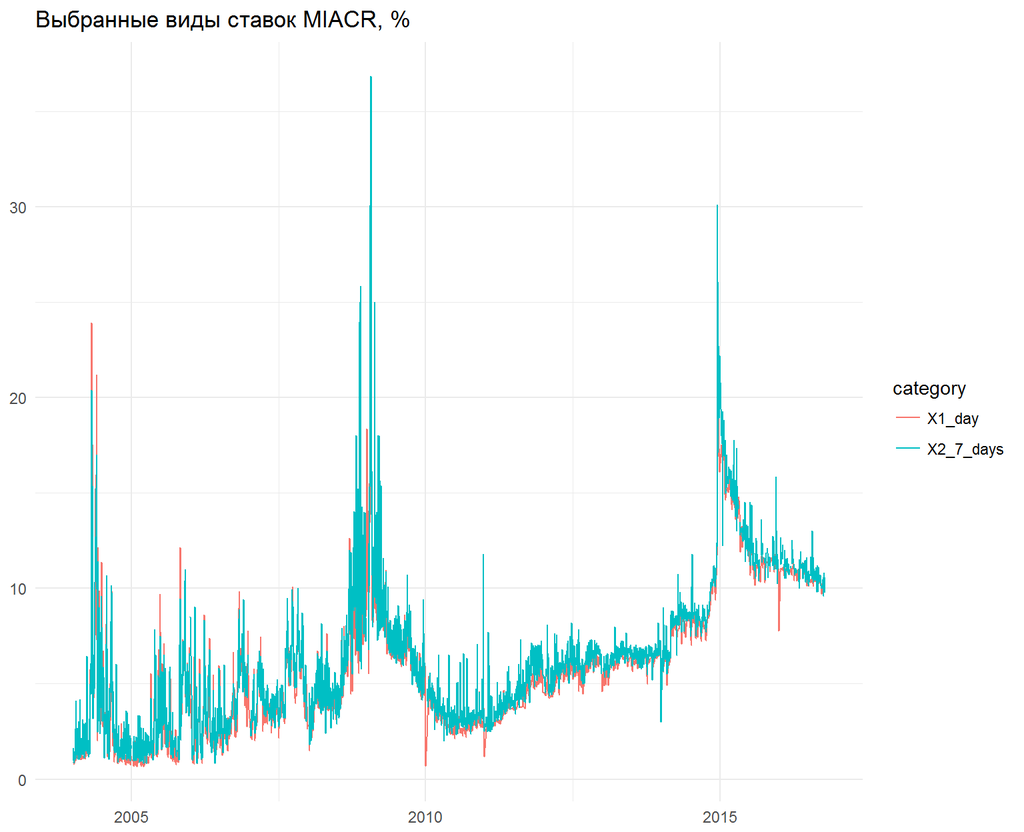

#### Mosprime

На основе анализа общей динамики ряда и выводов о доступности данных принимаем решение о включении в модель ставок Mosprime сроками 1 месяц и 3 месяца.

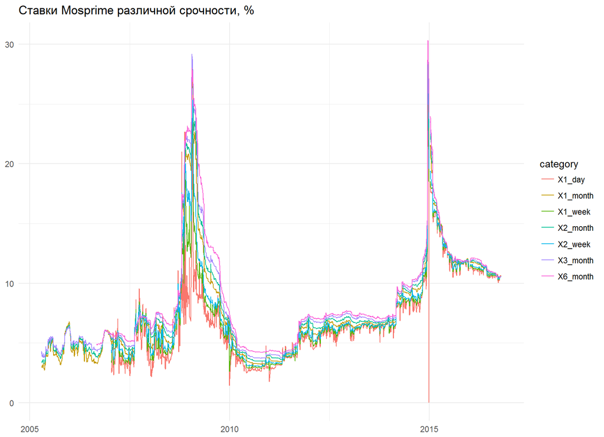

**Доля пропущенных значений в данных**

| X1_day | X1_month | X1_week | X2_month | X2_week | X3_month | X6_month |
| --- | --- | --- | --- | --- | --- | --- |
| 0.1536 | 0.002798 | 0.1549 | 0.002798 | 0.157 | 0.003148 | 0.1221 |

**Выбранное**

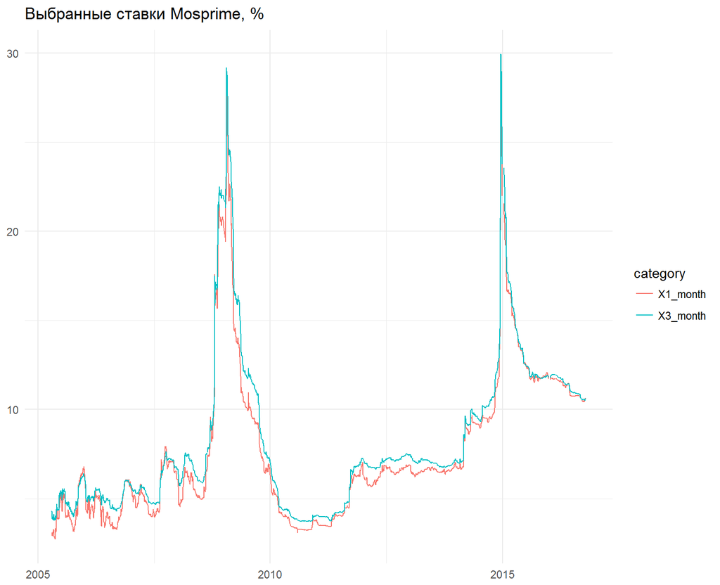

### Рынок корпоративных облигаций

Анализ общей динамики ряда позволяет убедиться в адекватности использования индекса IFX-Cbonds-YTM-eff в качестве одного из индикаторов процентного риска.

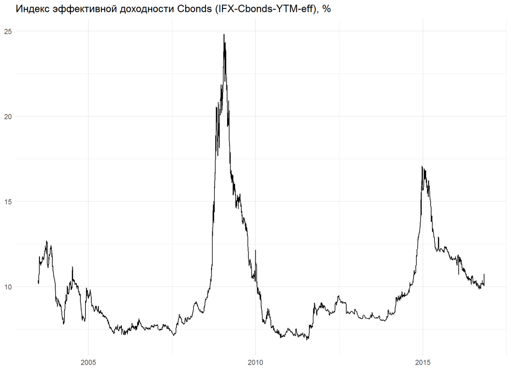

**Доля пропущенных значений в данных** *0*

### Рынок государственных облигаций

На основе анализа общей динамики ряда и выводов о доступности данных принимаем решение о включении в модель ставок ГКО-ОФЗ на срок 2 года и 3 года и спрэд между ставками на 3 года и на 1 год (сомнительно).

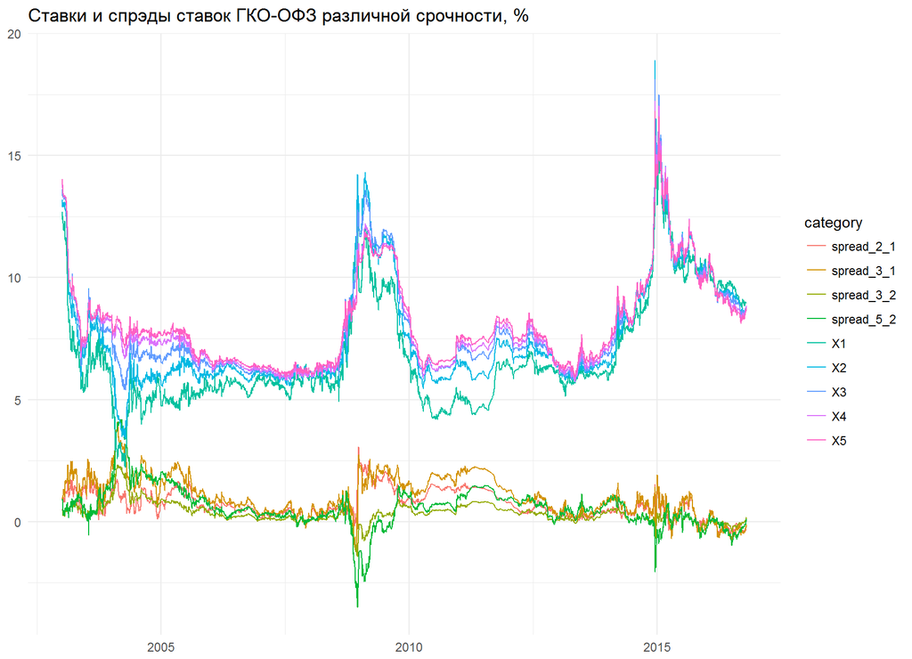

**Доля пропущенных значений в данных**

Table continues below

| spread_2_1 | spread_3_1 | spread_3_2 | spread_5_2 | X1 | X10 | X11 | X12 | X13 |
| --- | --- | --- | --- | --- | --- | --- | --- | --- |
| 0 | 0 | 0 | 0 | 0 | 0 | 0 | 0 | 0 |

Table continues below

| X14 | X15 | X16 | X17 | X18 | X19 | X2 | X20 | X21 | X22 | X23 | X24 | X25 |
| --- | --- | --- | --- | --- | --- | --- | --- | --- | --- | --- | --- | --- |
| 0 | 0 | 0 | 0 | 0 | 0 | 0 | 0 | 0 | 0 | 0 | 0 | 0 |

| X26 | X27 | X28 | X29 | X3 | X30 | X4 | X5 | X6 | X7 | X8 | X9 |
| --- | --- | --- | --- | --- | --- | --- | --- | --- | --- | --- | --- |
| 0 | 0 | 0 | 0 | 0 | 0 | 0 | 0 | 0 | 0 | 0 | 0 |

**Выбранное**

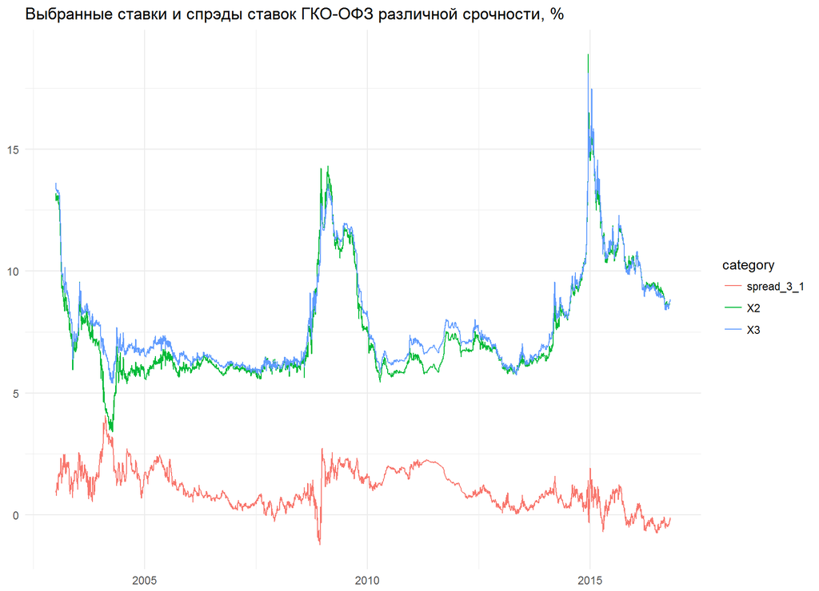

## Выделение первой главной компоненты

*1 шаг*: удаление пропущенных значений и нормализация данных.  
*2 шаг*: выделение первой главной компоненты различными способами.

### PCA

**Факторные нагрузки показателей по итогам метода главных компонент**

| ifx_cbonds | spread_3_1 | X1_day | X1_month | X2 | X2_7_days | X3 | X3_month |
| --- | --- | --- | --- | --- | --- | --- | --- |
| 0.4175 | -0.06839 | 0.2632 | 0.4093 | 0.4036 | 0.299 | 0.4029 | 0.4118 |

Доля объясненной дисперсии составила 79.21.

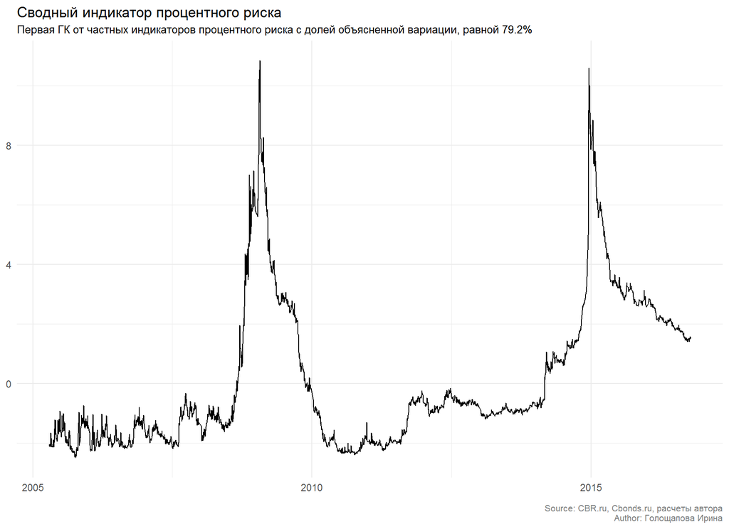

### Dynamic Factor Model

Динамическая факторная модель по методологии Doz, Gianone & Reichlin (2011).  
Выделяем один динамический фактор. Учитываем только один лаг каждой компоненты.

*Сравнение результатов*:  
- **красная линия** - dfa модель  
- **зеленая линия** - pca модель

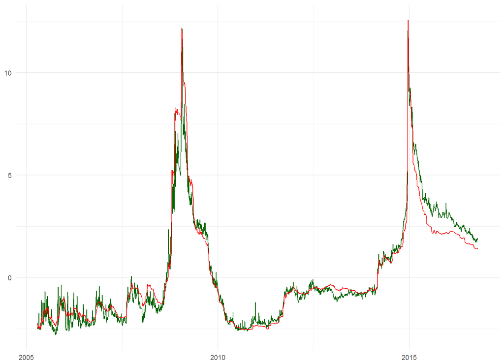

**Факторные нагрузки показателей по итогам расчета динамической факторной модели**

| ifx_cbonds | spread_3_1 | X1_day | X1_month | X2 | X2_7_days | X3 | X3_month |
| --- | --- | --- | --- | --- | --- | --- | --- |
| 0.3697 | -0.08566 | 0.3213 | 0.3939 | 0.3631 | 0.3365 | 0.3479 | 0.3964 |

### Functional PCA

Функциональный анализ: метод главных компонент - 3 способа реализации.  
- Метод classical: зеленая линия (доля объясненной дисперсии: 67.9%)  
- Метод robust pca: красная линия  
- Гибридный метод: синяя линия (доля объясненной дисперсии: 60.8%)

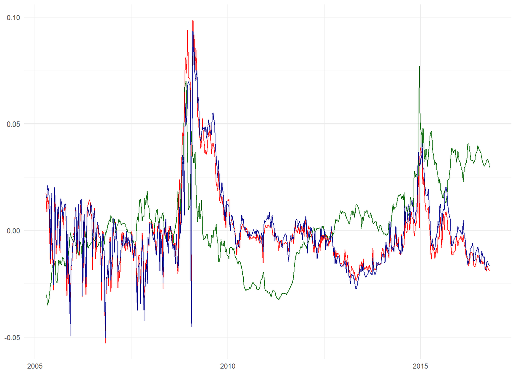

**Факторные нагрузки показателей по итогам расчетов по методам функционального анализа**

```
## Метод classical
```

*7.903*, *-62.05*, *4.363*, *16.3*, *8.278*, *5.744*, *4.729* and *14.74*

```
## Метод robust pca
```

*-18.65*, *6.164*, *21.85*, *-3.728*, *-7.494*, *17.81*, *-8.542* and *-7.409*

```
## Гибридный метод
```

*16.1*, *-4.55*, *-21.04*, *1.643*, *9.894*, *-19.15*, *11.71* and *5.388*

## Выделение событий реализации риска

### Экспертно-заданный порог

Визуальный анализ позволяет сделать предположение о величине порога, равной 4.

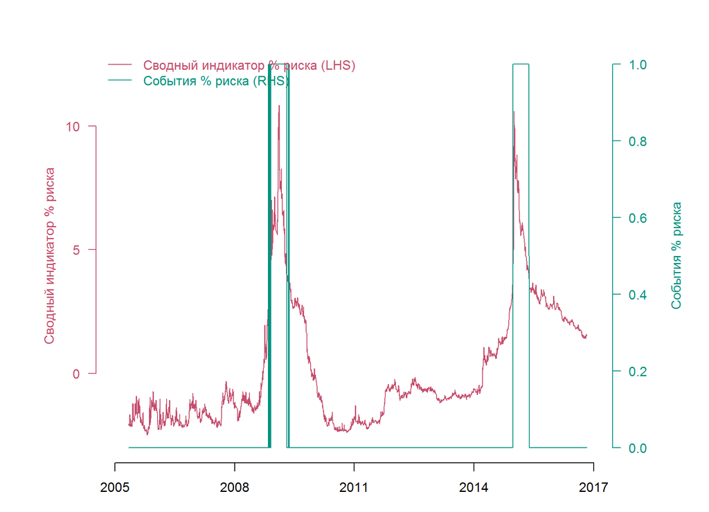

### Markov Switching

#### На константу

*Основные выводы:*  
- просто интерпретируемый и понятный результат, однако по качественным характеристикам модель далека от хорошей  
- явно присутствует автокорреляция (AR(1) и AR(2)), которую можно учесть  
- можно осуществлять прогноз на момент времени t+1 (следующий день) с помощью домножения вероятностей каждого режима в текущий день на соответствующие вероятности в матрице вероятностей перехода  
- для ежедневной выдачи результата модели необходим итеративный пересчет модели каждый день - **можно реализовать**. Различия в средних будет адаптироваться под новые данные и новые условия на рынке.  
- адекватность постановки итеративного пересчета лучше проверить с помощью кросс-валидации (тогда будет защищаемо).

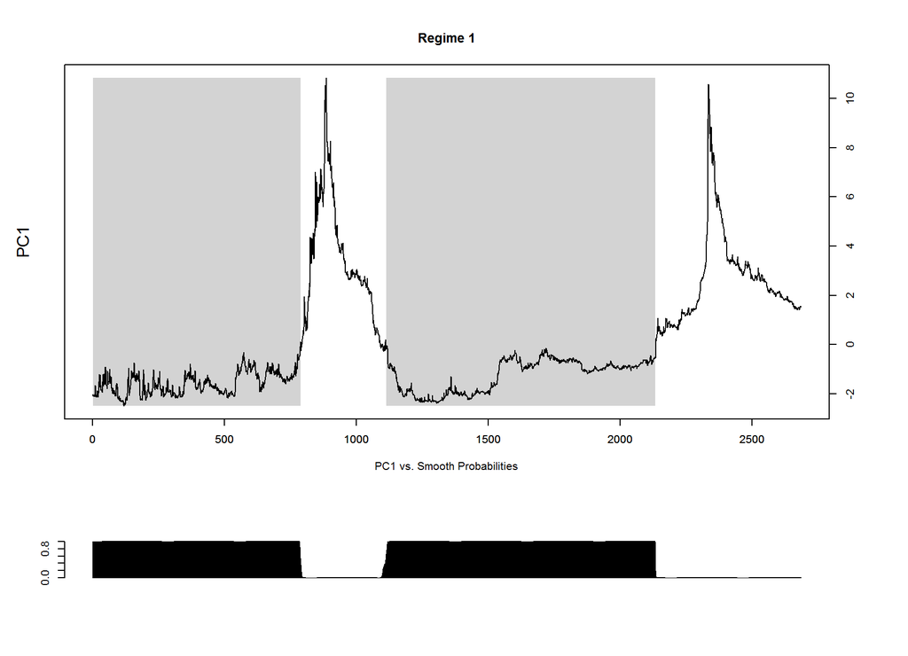

**Краткое описание результатов модели**

```
## Markov Switching Model
##
## Call: msmFit(object = lm_model, k = 2, sw = c(T, T), p = 0)
##
##        AIC      BIC    logLik
##   7073.686 7101.269 -3534.843
##
## Coefficients:
##
## Regime 1
## ---------
##                Estimate Std. Error t value  Pr(>|t|)
## (Intercept)(S)  -1.3806     0.0163 -84.699 < 2.2e-16 ***
## ---
## Signif. codes:  0 '***' 0.001 '**' 0.01 '*' 0.05 '.' 0.1 ' ' 1
##
## Residual standard error: 0.5953413
## Multiple R-squared:     0
##
## Standardized Residuals:
##           Min            Q1           Med            Q3           Max
## -1.109888e+00 -3.680320e-01  1.636312e-07  3.618897e-01  1.228425e+00
##
## Regime 2
## ---------
##                Estimate Std. Error t value  Pr(>|t|)
## (Intercept)(S)   2.8679     0.0815  35.189 < 2.2e-16 ***
## ---
## Signif. codes:  0 '***' 0.001 '**' 0.01 '*' 0.05 '.' 0.1 ' ' 1
##
## Residual standard error: 2.097018
## Multiple R-squared:     0
##
## Standardized Residuals:
##           Min            Q1           Med            Q3           Max
## -2.9855701183 -0.0021003441 -0.0011626596 -0.0009623055  7.9818926013
##
## Transition probabilities:
##              Regime 1    Regime 2
## Regime 1 0.9994482279 0.002291869
## Regime 2 0.0005517721 0.997708131
```

**Графики автокорреляции остатков модели**

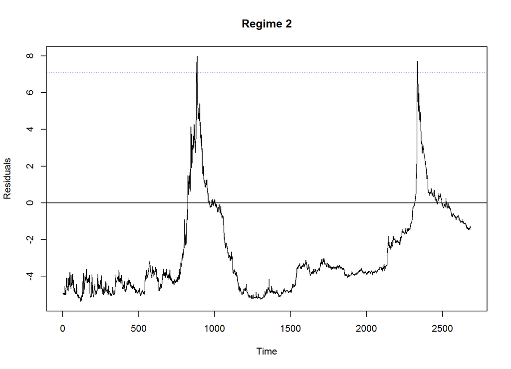

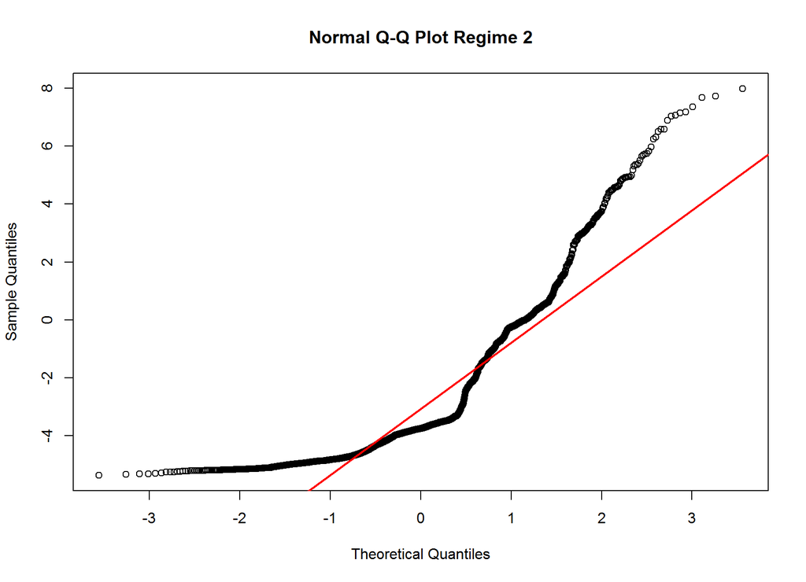

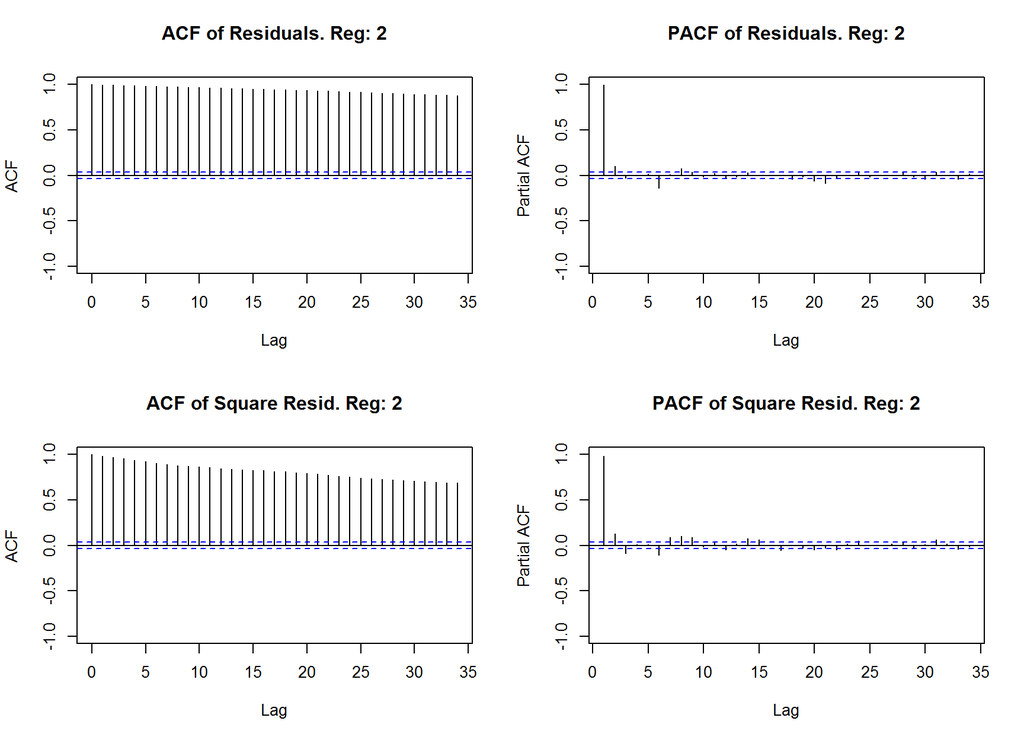

#### На константу с учетом AR(1)

*Основные выводы:*

- менее гладкий (устойчивый) и менее интерпретируемый результат - риск реализуется сильно чаще
- по качественным характеристикам модель значительно превосходит модель на константу
- по техническим характеристикам - примерно то же самое, что и модель на константу. Сложнее в реализации, но на времени ежедневного пересчета не должно отразиться сильно.

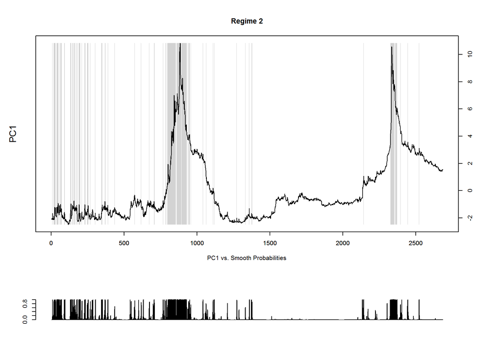

**Краткое описание результатов модели**

```
## Markov Switching Model
##
## Call: msmFit(object = lm_model, k = 2, sw = c(T, T, T), p = 1, control = list(parallel = F))
##
##         AIC       BIC   logLik
##   -4116.987 -4061.824 2062.494
##
## Coefficients:
##
## Regime 1
## ---------
##                Estimate Std. Error   t value Pr(>|t|)
## (Intercept)(S)  -0.0023     0.0017   -1.3529   0.1761
## PC1_1(S)         0.9965     0.0009 1107.2222   <2e-16 ***
## ---
## Signif. codes:  0 '***' 0.001 '**' 0.01 '*' 0.05 '.' 0.1 ' ' 1
##
## Residual standard error: 0.07573865
## Multiple R-squared: 0.9983
##
## Standardized Residuals:
##           Min            Q1           Med            Q3           Max
## -2.205219e-01 -3.908610e-02 -8.705654e-05  4.022650e-02  2.116314e-01
##
## Regime 2
## ---------
##                Estimate Std. Error  t value Pr(>|t|)
## (Intercept)(S)   0.0269     0.0258   1.0426   0.2971
## PC1_1(S)         0.9935     0.0062 160.2419   <2e-16 ***
## ---
## Signif. codes:  0 '***' 0.001 '**' 0.01 '*' 0.05 '.' 0.1 ' ' 1
##
## Residual standard error: 0.4641616
## Multiple R-squared: 0.9842
##
## Standardized Residuals:
##          Min           Q1          Med           Q3          Max
## -1.359898342 -0.005296145 -0.001400207  0.001472181  4.116995632
##
## Transition probabilities:
##            Regime 1  Regime 2
## Regime 1 0.96874728 0.1725501
## Regime 2 0.03125272 0.8274499
```

**Графики автокорреляции остатков модели**

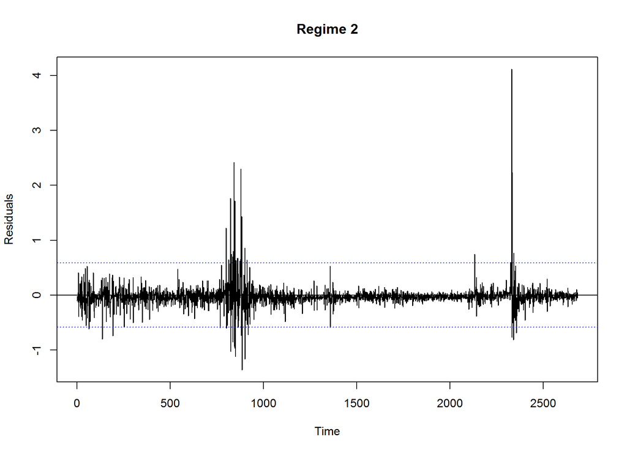

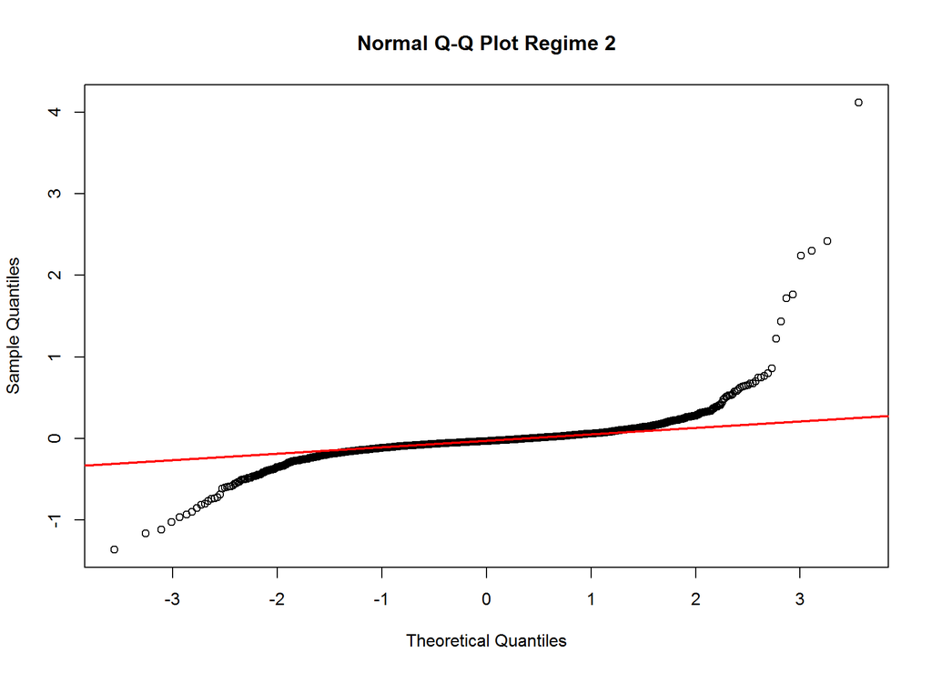

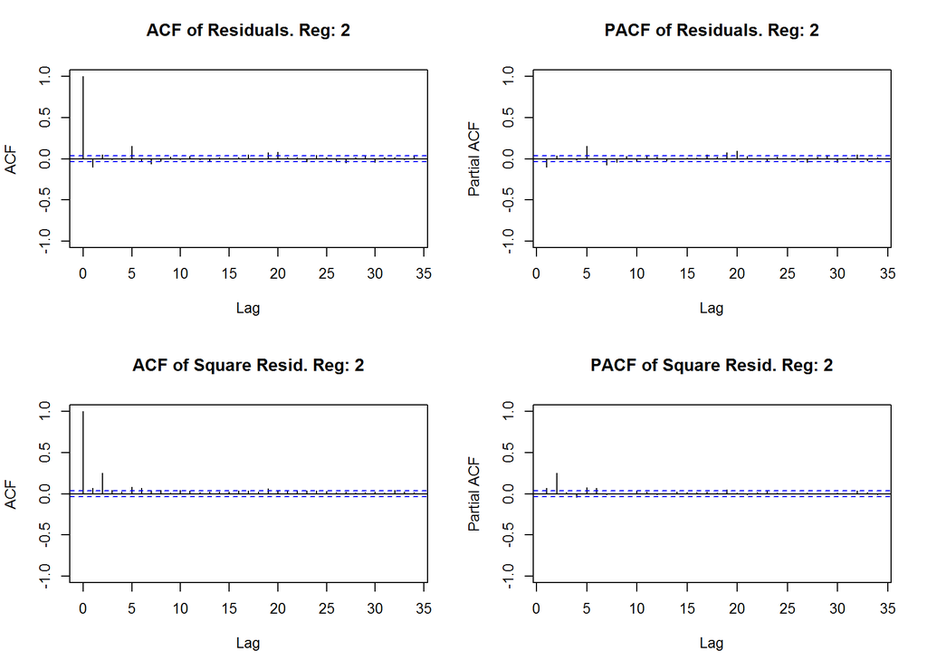

### DFAMS

Одновременная оптимизация динамической факторной модели и двухрежимной Markov-Switching.

*Основные выводы:*  
- очень, ооочень долго считается (за 4 часа 20 итераций из примерно 500-1000 необходимых)  
- позволяет осуществлять прогноз на основе предположений о динамике частных компонент.  
Но здесь следует принимать во внимание минус - модель не адаптируется под меняющиеся условия и через некоторое время может перестать производить адекватный результат (если произойдут новые нестандартные события по реализации рисков).